# Tugas Pertemuan 2

Syauqyi

2026-08-30

## Packages

```r
library(rio)
library(TTR)
library(forecast)
```

## 1. Import dan Eksplorasi Data

```r
data <- import("D:/SMT5/MPDW/data mpdw.xlsx", sheet = "orang 1")
str(data)
```

```
## 'data.frame':    100 obs. of  2 variables:
##  $ timestamp                   : chr  "1984-12" "1985-01" "1985-02" "1985-03" ...
##  $ global_temperature_anomaly_C: num  -0.05 0.22 -0.04 0.17 0.12 0.14 0.15 0.04 0.17 0.13 ...
```

```r
start.year  <- as.numeric(substr(data$timestamp[1], 1, 4))
start.month <- as.numeric(substr(data$timestamp[1], 6, 7))

data.ts <- ts(data$global_temperature_anomaly_C,
              start = c(start.year, start.month), frequency = 12)
```

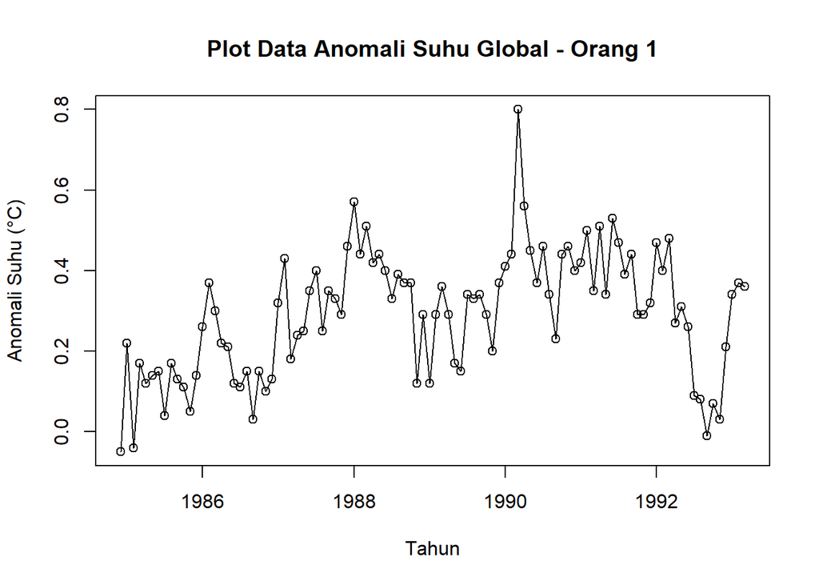

```r
ts.plot(data.ts, xlab = "Tahun", ylab = "Anomali Suhu (°C)",
        main = "Plot Data Anomali Suhu Global - Orang 1")
points(data.ts)
```

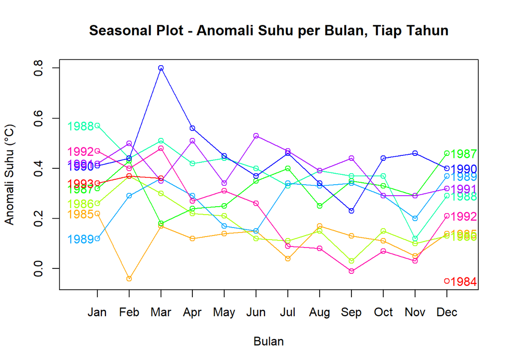

```r
seasonplot(data.ts, year.labels = TRUE, year.labels.left = TRUE,
           col = rainbow(ceiling(length(data.ts) / 12)),
           xlab = "Bulan", ylab = "Anomali Suhu (°C)",
           main = "Seasonal Plot - Anomali Suhu per Bulan, Tiap Tahun")
```

## 2. Pembagian Data (80% Latih, 20% Uji)

```r
n <- length(data.ts)
n_train <- floor(0.8 * n)

train.ts <- window(data.ts, end   = time(data.ts)[n_train])
test.ts  <- window(data.ts, start = time(data.ts)[n_train + 1])
```

## 3. Fungsi Akurasi

```r
akurasi <- function(actual, pred) {
  actual <- as.numeric(actual)
  pred   <- as.numeric(pred)
  e <- actual - pred

  c(
    SSE   = sum(e^2),
    MSE   = mean(e^2),
    RMSE  = sqrt(mean(e^2)),
    MAE   = mean(abs(e)),
    MAPE  = mean(abs(e / actual)) * 100,
    sMAPE = mean(abs(e) / ((abs(actual) + abs(pred)) / 2)) * 100
  )
}
```

## 4. Single Moving Average (SMA)

```r
m <- 4

sma        <- SMA(train.ts, n = m)
sma.fitted <- c(NA, sma[-length(sma)])
sma.test   <- rep(tail(sma, 1), length(test.ts))

idx <- (m + 1):n_train
akurasi.sma.train <- akurasi(train.ts[idx], sma.fitted[idx])
akurasi.sma.test  <- akurasi(test.ts, sma.test)
```

## 5. Double Moving Average (DMA)

```r
s1 <- SMA(train.ts, n = m)
s2 <- SMA(s1, n = m)
a  <- 2 * s1 - s2
b  <- (2 / (m - 1)) * (s1 - s2)

dma.value  <- a + b
dma.fitted <- c(NA, dma.value[-length(dma.value)])

a_last   <- as.numeric(tail(a, 1))
b_last   <- as.numeric(tail(b, 1))
h        <- 1:length(test.ts)
dma.test <- a_last + b_last * h

idx <- (2 * m):n_train
akurasi.dma.train <- akurasi(train.ts[idx], dma.fitted[idx])
akurasi.dma.test  <- akurasi(test.ts, dma.test)
```

## 6. Single Exponential Smoothing (SES)

```r
ses.model  <- HoltWinters(train.ts, beta = FALSE, gamma = FALSE)
ses.model$alpha
```

```
## [1] 0.4686838
```

```r
ses.fitted <- ses.model$fitted[, 1]
ses.test   <- forecast(ses.model, h = length(test.ts))$mean

akurasi.ses.train <- akurasi(train.ts[-1], ses.fitted)
akurasi.ses.test  <- akurasi(test.ts, ses.test)
```

## 7. Double Exponential Smoothing (DES)

```r
des.model  <- HoltWinters(train.ts, gamma = FALSE)
des.model$alpha
```

```
##     alpha
## 0.7246108
```

```r
des.model$beta
```

```
##      beta
## 0.2851777
```

```r
des.fitted <- des.model$fitted[, 1]
des.test   <- forecast(des.model, h = length(test.ts))$mean

akurasi.des.train <- akurasi(train.ts[-c(1, 2)], des.fitted)
akurasi.des.test  <- akurasi(test.ts, des.test)
```

## 8. Holt-Winters

```r
hw.model  <- HoltWinters(train.ts, seasonal = "additive")
hw.model$alpha
```

```
##     alpha
## 0.3715575
```

```r
hw.model$beta
```

```
## beta
##    0
```

```r
hw.model$gamma
```

```
##    gamma
## 0.256861
```

```r
hw.fitted <- hw.model$fitted[, 1]
hw.test   <- forecast(hw.model, h = length(test.ts))$mean

akurasi.hw.train <- akurasi(train.ts[-(1:12)], hw.fitted)
akurasi.hw.test  <- akurasi(test.ts, hw.test)
```

## 9. Perbandingan Kinerja Metode

```r
tabel.train <- rbind(SMA = akurasi.sma.train, DMA = akurasi.dma.train,
                      SES = akurasi.ses.train, DES = akurasi.des.train,
                      HW  = akurasi.hw.train)
tabel.test  <- rbind(SMA = akurasi.sma.test,  DMA = akurasi.dma.test,
                      SES = akurasi.ses.test,  DES = akurasi.des.test,
                      HW  = akurasi.hw.test)

tabel.train
```

```
##           SSE        MSE      RMSE        MAE     MAPE    sMAPE
## SMA 1.0044813 0.01321686 0.1149646 0.08904605 41.39699 33.84537
## DMA 1.4029659 0.01921871 0.1386316 0.11215183 47.45547 41.66513
## SES 0.9783637 0.01238435 0.1112850 0.08578355 44.06092 37.65540
## DES 1.4890537 0.01909043 0.1381681 0.10812792 66.16266 41.97505
## HW  0.8120392 0.01194175 0.1092783 0.08153085 35.17072 29.06496
```

```r
tabel.test
```

```
##          SSE        MSE      RMSE       MAE     MAPE    sMAPE
## SMA 1.138425 0.05692125 0.2385817 0.1920000 411.7788 63.48499
## DMA 3.341070 0.16705351 0.4087218 0.3595000 638.7072 84.95450
## SES 1.160588 0.05802939 0.2408929 0.1943213 414.8014 63.86628
## DES 2.873350 0.14366749 0.3790349 0.3308972 600.6860 81.88722
## HW  1.707219 0.08536094 0.2921660 0.2545819 447.3439 73.37761
```

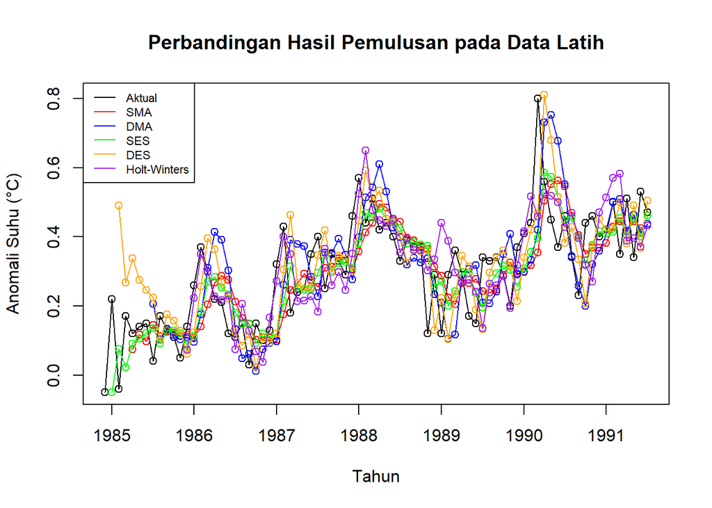

```r
sma.fitted <- as.numeric(sma.fitted)
dma.fitted <- as.numeric(dma.fitted)
ses.fitted.plot <- c(NA, as.numeric(ses.fitted))
des.fitted.plot <- c(NA, NA, as.numeric(des.fitted))
hw.fitted.plot  <- c(rep(NA, 12), as.numeric(hw.fitted))
start.train <- start(train.ts)
freq.train  <- frequency(train.ts)

sma.fitted.ts <- ts(sma.fitted,      start = start.train, frequency = freq.train)
dma.fitted.ts <- ts(dma.fitted,      start = start.train, frequency = freq.train)
ses.fitted.ts <- ts(ses.fitted.plot, start = start.train, frequency = freq.train)
des.fitted.ts <- ts(des.fitted.plot, start = start.train, frequency = freq.train)
hw.fitted.ts  <- ts(hw.fitted.plot,  start = start.train, frequency = freq.train)

plot(train.ts, type = "o",
     ylim = range(c(train.ts, sma.fitted, dma.fitted, ses.fitted.plot,
                     des.fitted.plot, hw.fitted.plot), na.rm = TRUE),
     xlab = "Tahun", ylab = "Anomali Suhu (°C)",
     main = "Perbandingan Hasil Pemulusan pada Data Latih")
lines(sma.fitted.ts, col = "red",    type = "o")
lines(dma.fitted.ts, col = "blue",   type = "o")
lines(ses.fitted.ts, col = "green",  type = "o")
lines(des.fitted.ts, col = "orange", type = "o")
lines(hw.fitted.ts,  col = "purple", type = "o")
legend("topleft", c("Aktual", "SMA", "DMA", "SES", "DES", "Holt-Winters"),
       col = c("black", "red", "blue", "green", "orange", "purple"), lty = 1, cex = 0.7)
```

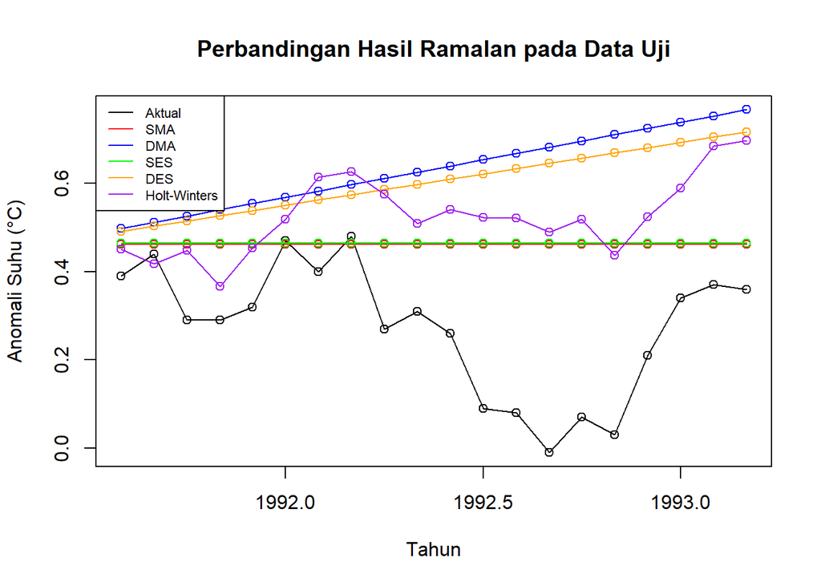

```r
sma.test <- as.numeric(sma.test)
dma.test <- as.numeric(dma.test)
ses.test <- as.numeric(ses.test)
des.test <- as.numeric(des.test)
hw.test  <- as.numeric(hw.test)
start.test <- start(test.ts)
freq.test  <- frequency(test.ts)

sma.test.ts <- ts(sma.test, start = start.test, frequency = freq.test)
dma.test.ts <- ts(dma.test, start = start.test, frequency = freq.test)
ses.test.ts <- ts(ses.test, start = start.test, frequency = freq.test)
des.test.ts <- ts(des.test, start = start.test, frequency = freq.test)
hw.test.ts  <- ts(hw.test,  start = start.test, frequency = freq.test)

plot(test.ts, type = "o",
     ylim = range(c(test.ts, sma.test, dma.test, ses.test, des.test, hw.test)),
     xlab = "Tahun", ylab = "Anomali Suhu (°C)",
     main = "Perbandingan Hasil Ramalan pada Data Uji")
lines(sma.test.ts, col = "red",    type = "o")
lines(dma.test.ts, col = "blue",   type = "o")
lines(ses.test.ts, col = "green",  type = "o")
lines(des.test.ts, col = "orange", type = "o")
lines(hw.test.ts,  col = "purple", type = "o")
legend("topleft", c("Aktual", "SMA", "DMA", "SES", "DES", "Holt-Winters"),
       col = c("black", "red", "blue", "green", "orange", "purple"), lty = 1, cex = 0.7)
```

```r
metode.terbaik <- rownames(tabel.test)[which.min(tabel.test[, "MAPE"])]
metode.terbaik
```

```
## [1] "SMA"
```

## 10. Kesimpulan

Jika dilihat dari akurasi maka SMA menghasilkan akurasi terbaik. tapi ini tidak berarti SMA mampu ataupun berhasil menangkap pola dari data yang ada. nyatanya seluruh metode pemulusan gagal menangkap pola yang ada. metode SMA atau SES cocok untuk data yang memiliki pola stasioner dan hanya naik turun karena noise. ketika dilakukan prediksi dengan SMA ataupun SES maka prediksi akan menghasilkan garis lurus, harapannya data akan naik turun di sekitar garis prediksi. metode DMA dan DES cocok untuk data yang memiliki pola konstan dan terdapat tren (naik atau turun). ketika dilakukan prediksi dengan DMA ataupun DES maka prediksi akan menghasilkan garis lurus (naik atau turun) sesuai trend pada data latih. pada kasus data ini data latih memiliki trend naik namun pada data uji trend nya cenderung sedikit turun. metode holt-winters cocok untuk data yang memiliki pola seasonal. pada hasil eksplorasi data ditemukan pola data tidaklah stasioner, naik, ataupun turun, data cenderung naik-turun. ketika dilihat pola tahunan nya pun tidak terlihat pola yang cukup signifikan untuk disebut seragam antar tahun. jadi prediksi holt-winters tidaklah cukup akurat karena memang tidak ada pola tahunan, ini juga diperparah karena holt-winters juga menangkap trend maka prediksi nya akan cenderung naik namun data uji mengalami perubahan trend yaitu malah cenderung turun. SMA memiliki kesalahan paling kecil karena perubahan trend data uji. prediksi SMA tetap jauh dari benar namun karena prediksi-prediksi lain memiliki trend naik maka kesalahan metode lain akan semakin tinggi.